# Trabajo TD 02

### 5.2.4 Método PROMETHEE II (medias)

```r
tab.Pthee.ii.mean = multicriterio.metodo.promethee_ii_med(matriz_decision,
                                                          pesos.criterios,
                                                          tab.fpref)
tab.Pthee.ii.mean
```

```
## $tabla.indices
##           A1      A2        A3        A4        A5
## A1 0.0000000 0.50000 0.5250000 0.5088888 0.5971434
## A2 0.2212481 0.00000 0.1433634 0.1100000 0.5550000
## A3 0.1663888 0.30500 0.0000000 0.1121434 0.5599665
## A4 0.1425000 0.38125 0.4250000 0.0000000 0.5588888
## A5 0.2162500 0.10000 0.1437500 0.0737500 0.0000000
##
## $vflujos.netos
##          A1          A2          A3          A4          A5
##  0.34616133 -0.06415961 -0.02340368  0.17571414 -0.43431217
##
## $tablarelacionsupera
##    A1 A2 A3 A4 A5
## A1  0  1  1  1  1
## A2  0  0  0  0  1
## A3  0  1  0  0  1
## A4  0  1  1  0  1
## A5  0  0  0  0  0
```

**Representamos como un grafo:**

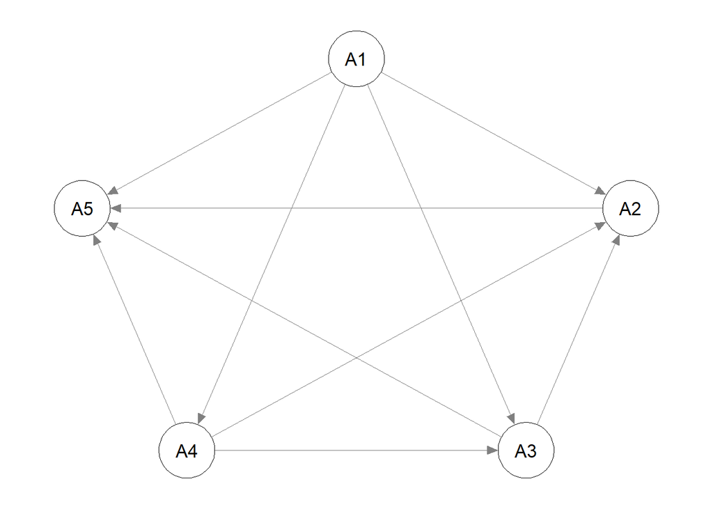

```r
qgraph::qgraph(tab.Pthee.ii.mean$tablarelacionsupera)
```

**Comparativa Promethee II: sin medias y con medias.**

La ordenación que establecen sería la siguiente:

```r
order(tab.Pthee.ii$vflujos.netos, decreasing = T)
```

```
## [1] 1 4 3 2 5
```

```r
order(tab.Pthee.ii.mean$vflujos.netos, decreasing = T)
```

```
## [1] 1 4 3 2 5
```

Obtenemos el mismo orden para ambos siendo el orden de preferencia el siguiente: A1: Dell XPS 16, A4: HP Envy 16, A3: ThinkPad T14s, A2: MacBook Air 15, A5: Aspire 5

### 5.2.5 Resolución con Promethee Windows

```r
res=multicriterio.metodo.promethee_windows(matriz_decision,
                                        tab.fpref,
                                        pesos.criterios)
res01=multicriterio.metodo.promethee_windows_kableExtra(res)
```

Tabla que muestra la información por apartados introducidos en el problema resuelto con Promethee:

```r
res01$tabEscenario %>%
  kable_styling(latex_options = c("striped","condensed",
                                  "HOLD_position","scale_down"),
                position = "center")
```

|  | Criterio1 | Criterio2 | Criterio3 | Criterio4 | Criterio5 | Criterio6 | Criterio7 | Criterio8 |
| --- | --- | --- | --- | --- | --- | --- | --- | --- |
| **Preferencias** |  |  |  |  |  |  |  |  |
| Pesos | 0.25 | 0.3 | 0.15 | 0.05 | 0.05 | 0.1 | 0.05 | 0.05 |
| Funciones Preferencias | V-shape (3) | Usual (1) | U-shape (2) | Level (4) | Linear (5) | Gaussian (6) | V-shape (3) | Level (4) |
| Q: Indiferencia | 1000 | 0 | 4 | 500 | 3 | 0 | 1 | 1 |
| P: Preferencia | 2000 | 0 | 0 | 1000 | 5 | 0 | 2 | 3 |
| S: Gausiano | 0 | 0 | 0 | 0 | 0 | 1.5 | 0 | 0 |
| Minimo | -2400 | 8500 | 8 | 1 | 512 | 6 | -2.1 | 14 |
| **Estadísticas** |  |  |  |  |  |  |  |  |
| Maximo | -750 | 16500 | 32 | 8 | 1000 | 17 | -1.3 | 16 |
| Media | -1540 | 13060 | 17.6 | 3.6 | 707.2 | 10.6 | -1.7 | 15.38 |
| Desviacion Tipica | 537.96 | 2598.92 | 7.84 | 2.42 | 239.07 | 3.77 | 0.28 | 0.74 |
| A1 | -2400 | 16500 | 32 | 8 | 1000 | 10 | -2.1 | 16 |
| **Evaluaciones** |  |  |  |  |  |  |  |  |
| A2 | -1550 | 12800 | 16 | 3 | 512 | 17 | -1.5 | 15.3 |
| A3 | -1700 | 13500 | 16 | 2 | 512 | 12 | -1.3 | 14 |
| A4 | -1300 | 14000 | 16 | 4 | 1000 | 8 | -1.9 | 16 |
| A5 | -750 | 8500 | 8 | 1 | 512 | 6 | -1.7 | 15.6 |

Tabla que muestra la ordenación de las alternativas: ei:

```r
res01$tabAcciones %>%
  kable_styling(latex_options = c("striped","condensed",
                                  "HOLD_position","scale_down"),
                position = "center")
```

|  | Rango | Phi | Phi.mas | Phi.menos |
| --- | --- | --- | --- | --- |
| A1 | 1 | 0.3462 | 0.5328 | 0.1866 |
| A4 | 2 | 0.1757 | 0.3769 | 0.2012 |
| A3 | 3 | -0.0234 | 0.2859 | 0.3093 |
| A2 | 4 | -0.0642 | 0.2574 | 0.3216 |
| A5 | 5 | -0.4343 | 0.1334 | 0.5677 |

La ordenación de las alternativas es:

```r
rownames(res$Acciones)
```

```
## [1] "A1" "A4" "A3" "A2" "A5"
```

Con Promethee Windows obtenemos la misma ordenación que en Promethee II